# Unit 6 — Linear Regression

Units 4 and 5 asked whether groups differ. Regression asks a wider question: how does an outcome change as one or more predictors change, and how well does a straight line describe that? A continuous predictor gives a rate — so much more outcome per unit of predictor. A categorical one gives a difference between groups. One model holds both.

Every part of this notebook uses one dataset: exam results for four thousand pupils in sixty-five London schools. Five questions, in order:

1. Does reading at 11 predict exam results at 16? *(Model 1)*
2. Do girls and boys with the same reading score differ at 16? *(Model 2)*
3. Does the slope differ by sex? *(Model 3, an interaction)*
4. Do pupils at single-sex schools score differently from the same sex at mixed schools, at the same reading score? *(Model 4)*
5. How far can the standard errors trust four thousand pupils who sit in sixty-five schools?

Checking a model's assumptions — the residuals, influence, collinearity — is Unit 7's. This unit fits models and reads them.

```python
import math9102 as m9
import numpy as np
import pandas as pd
import statsmodels.api as sm
import statsmodels.formula.api as smf
from scipy import stats

m9.use_house_style()
```

## Part 1 — Does reading at 11 predict exam results at 16?

The data were built to show how pupils' results vary between schools. Two variables carry Model 1:

- `normexam`, the exam score at 16;
- `standlrt`, a reading test score at 11.

Both are standardised: a score of zero is the average pupil, and one unit is one standard deviation.

```python
regression = m9.load_regression()
regression.shape
```

```
(4059, 15)
```

```python
# No missing values on anything this unit uses: the listwise cost is nothing.
missing = m9.missingness(regression, ["normexam", "standlrt", "girl", "schgend", "school"])
print(missing.attrs["summary"])
m9.describe(regression, ["normexam", "standlrt"])
```

```
Listwise deletion across these 5 column(s) keeps 4059 of 4059 rows (loses 0, 0.0%).
```

|  | n | missing | mean | sd | se | median | iqr | min | max | skew | kurtosis |
| --- | --- | --- | --- | --- | --- | --- | --- | --- | --- | --- | --- |
| normexam | 4059 | 0 | -0.000 | 0.999 | 0.016 | 0.004 | 1.378 | -3.666 | 3.666 | 0.004 | -0.018 |
| standlrt | 4059 | 0 | 0.002 | 0.993 | 0.016 | 0.040 | 1.240 | -2.935 | 3.016 | -0.128 | 0.072 |

### Look before you model

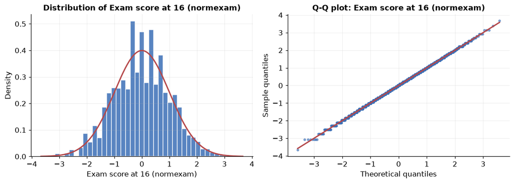

```python
m9.normality_panel(regression["normexam"], label="Exam score at 16 (normexam)");
```

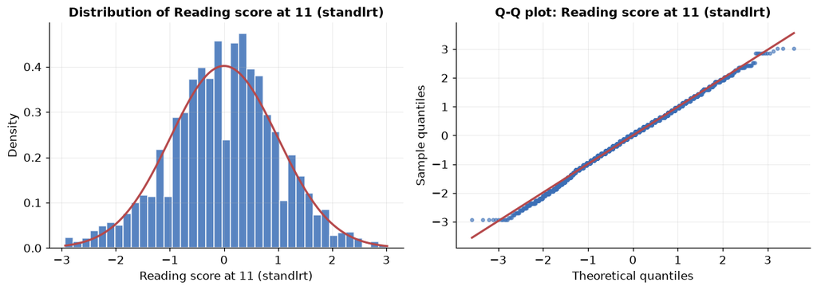

```python
m9.normality_panel(regression["standlrt"], label="Reading score at 11 (standlrt)");
```

The outcome's own shape is not an assumption of regression. What the model assumes is about its **residuals**, the part of each score the line does not account for, and that is Unit 7's subject. Look at both variables anyway, to know what you are predicting and from what: here, two roughly symmetric scores with no gaps or impossible values.

### Scatter, then *r*

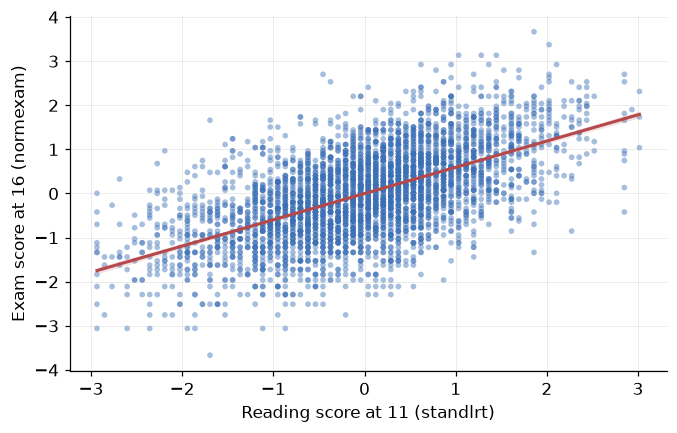

```python
m9.scatter_with_fit(regression, "standlrt", "normexam",
                    xlabel="Reading score at 11 (standlrt)",
                    ylabel="Exam score at 16 (normexam)")
```

```python
correlation = stats.pearsonr(regression["standlrt"], regression["normexam"])
m9.report_correlation(regression, "standlrt", "normexam", correlation,
                      x_label="reading score at 11", y_label="exam score at 16")
```

The relationship between reading score at 11 and exam score at 16 was examined using a Pearson correlation. There was a large positive correlation, which was statistically significant: *r*(4057) = .59, *p* < .001, *n* = 4059. The correlation describes association only and does not on its own establish that one variable causes the other.

A rising cloud, wide at every reading score. The correlation says the two move together; the regression says by how much.

### Fit Model 1

The formula reads "exam score, predicted from reading score". The outcome goes on the left of the tilde.

```python
model1 = smf.ols("normexam ~ standlrt", data=regression).fit()
print(model1.summary())
```

```
                            OLS Regression Results
==============================================================================
Dep. Variable:               normexam   R-squared:                       0.350
Model:                            OLS   Adj. R-squared:                  0.350
Method:                 Least Squares   F-statistic:                     2185.
Date:                Mon, 02 Nov 2026   Prob (F-statistic):               0.00
Time:                        08:34:21   Log-Likelihood:                -4880.3
No. Observations:                4059   AIC:                             9765.
Df Residuals:                    4057   BIC:                             9777.
Df Model:                           1
Covariance Type:            nonrobust
==============================================================================
                 coef    std err          t      P>|t|      [0.025      0.975]
------------------------------------------------------------------------------
Intercept     -0.0012      0.013     -0.094      0.925      -0.026       0.024
standlrt       0.5951      0.013     46.744      0.000       0.570       0.620
==============================================================================
Omnibus:                        2.846   Durbin-Watson:                   1.678
Prob(Omnibus):                  0.241   Jarque-Bera (JB):                2.856
Skew:                          -0.039   Prob(JB):                        0.240
Kurtosis:                       3.104   Cond. No.                         1.01
==============================================================================

Notes:
[1] Standard Errors assume that the covariance matrix of the errors is correctly specified.
```

The summary is long. Four things in it matter here, and the cells below take them one at a time.

### How good is the model? The mean as a baseline

Without a predictor, your best guess for any pupil is the mean exam score. The **total** sum of squares measures how far the scores sit from that mean. The line takes some of that distance away (the **model** sum of squares); what is left is the **residual** sum of squares.

```python
ss_total, ss_model, ss_resid = model1.centered_tss, model1.ess, model1.ssr
print(f"total {ss_total:.1f} = model {ss_model:.1f} + residual {ss_resid:.1f}")
print(f"R squared = model / total = {ss_model / ss_total:.3f}")
```

```
total 4049.4 = model 1417.5 + residual 2631.9
R squared = model / total = 0.350
```

```python
# The sums of squares, the mean squares and F, as a table.
sm.stats.anova_lm(model1)
```

|  | df | sum_sq | mean_sq | F | PR(>F) |
| --- | --- | --- | --- | --- | --- |
| standlrt | 1.0 | 1417.500911 | 1417.500911 | 2185.011262 | 0.0 |
| Residual | 4057.0 | 2631.932062 | 0.648738 | NaN | NaN |

*F* is the model's mean square over the residual mean square: how much the line accounts for per degree of freedom it uses, against how much is left per degree of freedom remaining. It tests one null hypothesis — that the line does no better than the mean.

**Read *R²* as a description of this sample.** It is the share of the variation in exam scores the line accounts for here. It is not the share of exam success that reading *causes*, and a sample with a narrower range of readers would give a smaller *R²* for the same slope.

### Reading the coefficients

```python
pd.DataFrame({"b": model1.params, "p": model1.pvalues}).join(
    model1.conf_int().set_axis(["CI low", "CI high"], axis=1))
```

|  | b | p | CI low | CI high |
| --- | --- | --- | --- | --- |
| Intercept | -0.001191 | 0.924941 | -0.025977 | 0.023595 |
| standlrt | 0.595057 | 0.000000 | 0.570099 | 0.620015 |

- **The slope** is the difference in predicted exam score between two pupils one unit apart in reading score. Its interval says which slopes the data are consistent with.
- **The intercept** is the prediction when every predictor is zero — here, for a pupil of average reading score. Its *p*-value tests whether that prediction is zero, which is rarely a question anyone asked. Do not report it as a finding.

### Using the model to predict

```python
# Predictions for three new pupils: one SD below the mean, at it, above it.
new_pupils = pd.DataFrame({"standlrt": [-1, 0, 1]})
model1.predict(new_pupils)
```

```
0   -0.596248
1   -0.001191
2    0.593866
dtype: float64
```

A prediction is the line's value, not a promise about any one pupil: the cloud around the line is wide. `get_prediction` gives both kinds of interval.

```python
model1.get_prediction(new_pupils).summary_frame(alpha=0.05)
```

|  | mean | mean_se | mean_ci_lower | mean_ci_upper | obs_ci_lower | obs_ci_upper |
| --- | --- | --- | --- | --- | --- | --- |
| 0 | -0.596248 | 0.017957 | -0.631454 | -0.561041 | -2.175751 | 0.983255 |
| 1 | -0.001191 | 0.012642 | -0.025977 | 0.023595 | -1.580496 | 1.578114 |
| 2 | 0.593866 | 0.017925 | 0.558723 | 0.629008 | -0.985636 | 2.173367 |

`mean_ci_lower` and `mean_ci_upper` bound the **average** exam score of pupils with that reading score: four thousand pupils pin it down, so the interval is narrow. `obs_ci_lower` and `obs_ci_upper` bound **one** pupil's score, and are far wider, because a single pupil carries the residual as well. Both hold only inside the range of reading scores the model saw.

### Standardised coefficients

Standardising both variables puts the slope in standard-deviation units, so slopes on different scales can be set side by side. patsy's `standardize()` does it inside the formula.

```python
beta = smf.ols("standardize(normexam) ~ standardize(standlrt)", data=regression).fit()
beta.params
```

```
Intercept               -5.946307e-16
standardize(standlrt)    5.916496e-01
dtype: float64
```

These two variables were already standardised in the data, so the slope barely moves. **Do not standardise a binary predictor.** "One standard deviation of being a girl" describes nobody; its unstandardised coefficient, the gap between the groups, is already the readable number.

### Reporting Model 1

```python
m9.report_regression(
    model1,
    outcome_label="exam score at 16",
    predictor_labels={"standlrt": "reading score at 11"},
)
```

A linear regression model was fitted to predict exam score at 16 from 1 predictor term (*N* = 4,059). The overall model was statistically significant, *F*(1, 4057) = 2185.01, *p* < .001. *R²* = .350: the model accounts for 35.0% of the variance in exam score at 16 in this sample, large by Cohen's convention for *R²* (adjusted *R²* = .350).

Coefficients, with 95% confidence intervals: reading score at 11, *b* = 0.595 [0.570, 0.620], *p* < .001.

Fitted equation: exam score at 16 = -0.001 + 0.595 × reading score at 11

The model describes an association in these data. It does not establish that reading score at 11 causes exam score at 16.

The paragraph gives *F* with both degrees of freedom, *R²* in words, the coefficient with its interval, the fitted equation, and what the model does not establish. With one predictor it says nothing about "holding other factors constant": there are no other factors in the model to hold.

## Part 2 — Do girls and boys with the same reading score differ at 16?

`girl` holds text, "boy" or "girl". The formula turns it into a **dummy** variable: one for girls, zero for boys. Boys come first alphabetically, so they are the **reference** category, and the coefficient is the difference between girls and boys.

```python
m9.frequency(regression, "girl")
```

| girl | count | percent | valid_percent |
| --- | --- | --- | --- |
| boy | 1623 | 39.99 | 39.99 |
| girl | 2436 | 60.01 | 60.01 |

```python
model2 = smf.ols("normexam ~ standlrt + girl", data=regression).fit()
pd.DataFrame({"Model 1": model1.params, "Model 2": model2.params})
```

|  | Model 1 | Model 2 |
| --- | --- | --- |
| Intercept | -0.001191 | -0.103184 |
| girl[T.girl] | NaN | 0.169960 |
| standlrt | 0.595057 | 0.590596 |

Reading's coefficient moves slightly when `girl` enters. In Model 2 each coefficient is read **holding the other predictor constant**: the reading slope for pupils of the same sex, and the girl–boy gap for pupils with the same reading score.

### Two parallel lines

Model 2 gives boys and girls the same slope and different intercepts. The gap between the lines is the `girl` coefficient, and because the lines are parallel it is the same at every reading score.

```python
lines = pd.DataFrame({"standlrt": [0, 0], "girl": ["boy", "girl"]})
lines["predicted"] = model2.predict(lines)
lines
```

|  | standlrt | girl | predicted |
| --- | --- | --- | --- |
| 0 | 0 | boy | -0.103184 |
| 1 | 0 | girl | 0.066776 |

**Read the gap where you say you read it.** The intercepts are predictions at `standlrt` = 0, the pupil of average reading score. Evaluate the lines at a different reading score and the two predictions both move — the gap does not, but a table of predictions at that score no longer describes "the average pupil".

### Comparing Model 2 with Model 1

Does adding `girl` improve the model? Two nested models — one the other plus something — are compared with an *F*-test for the extra terms. **Both must be fitted on the same rows.** Models fitted on different rows differ in their data as well as their predictors, and neither *F* nor the change in *R²* can separate the two. These data have no missing values, so the rows are the same; the check below compares the rows themselves rather than assuming it.

```python
assert model1.model.data.row_labels.equals(model2.model.data.row_labels)

# The F-test for the extra term, from statsmodels.
sm.stats.anova_lm(model1, model2)
```

|  | df_resid | ssr | df_diff | ss_diff | F | Pr(>F) |
| --- | --- | --- | --- | --- | --- | --- |
| 0 | 4057.0 | 2631.932062 | 0.0 | NaN | NaN | NaN |
| 1 | 4056.0 | 2603.875184 | 1.0 | 28.056878 | 43.703592 | 4.317291e-11 |

```python
# The same test, narrated. It refuses two models fitted on different rows.
m9.report_model_comparison(model1, model2,
                           predictor_labels={"standlrt": "reading score at 11",
                                             "girl[T.girl]": "sex (girl against boy)"})
```

Adding sex (girl against boy) to the model with reading score at 11 (both fitted on the same *N* = 4,059 rows) changed *R²* by .007, from .350 to .357. This was a statistically significant improvement, *F*(1, 4056) = 43.70, *p* < .001.

```python
m9.report_regression(
    model2,
    outcome_label="exam score at 16",
    predictor_labels={"standlrt": "reading score at 11",
                      "girl[T.girl]": "girl (against boy)"},
)
```

A linear regression model was fitted to predict exam score at 16 from 2 predictor terms (*N* = 4,059). The overall model was statistically significant, *F*(2, 4056) = 1125.86, *p* < .001. *R²* = .357: the model accounts for 35.7% of the variance in exam score at 16 in this sample, large by Cohen's convention for *R²* (adjusted *R²* = .357).

Coefficients, with 95% confidence intervals: girl (against boy), *b* = 0.170 [0.120, 0.220], *p* < .001; reading score at 11, *b* = 0.591 [0.566, 0.615], *p* < .001. Each coefficient is read holding the other predictors constant.

Fitted equation: exam score at 16 = -0.103 + 0.170 × girl (against boy) + 0.591 × reading score at 11

The model describes an association in these data. It does not establish that any of these predictors causes exam score at 16.

*R²* never falls when a predictor is added, even a useless one: the line can always fit these particular pupils at least as well. Adjusted *R²* charges for each predictor, which is why the report gives both. A rise in *R²* is evidence only through its test.

## Part 3 — Does the slope differ by sex?

Model 2 forces girls and boys onto one slope. An **interaction** lets the slope differ: `standlrt * girl` means `standlrt + girl + standlrt:girl`, and the last term is the difference between the girls' slope and the boys'.

```python
# The product is built by the formula, so it always matches its parts.
model3 = smf.ols("normexam ~ standlrt * girl", data=regression).fit()
model3.params
```

```
Intercept               -0.103045
girl[T.girl]             0.169902
standlrt                 0.592815
standlrt:girl[T.girl]   -0.004031
dtype: float64
```

Build the interaction in the formula rather than from a column of products. The dataset carries such a column, `interaction`; it happens to be right, but a model built from it would not know it was an interaction, and could not be checked against its parts.

```python
interaction = "standlrt:girl[T.girl]"
low, high = model3.conf_int().loc[interaction]
print(f"interaction b = {model3.params[interaction]:.3f}, "
      f"95% CI [{low:.3f}, {high:.3f}], p = {model3.pvalues[interaction]:.3f}")
```

```
interaction b = -0.004, 95% CI [-0.054, 0.046], p = 0.874
```

```python
m9.report_regression(
    model3,
    outcome_label="exam score at 16",
    predictor_labels={"standlrt": "reading score at 11",
                      "girl[T.girl]": "girl (against boy)",
                      interaction: "reading × girl"},
)
```

A linear regression model was fitted to predict exam score at 16 from 3 predictor terms (*N* = 4,059). The overall model was statistically significant, *F*(3, 4055) = 750.40, *p* < .001. *R²* = .357: the model accounts for 35.7% of the variance in exam score at 16 in this sample, large by Cohen's convention for *R²* (adjusted *R²* = .357).

Coefficients, with 95% confidence intervals: girl (against boy), *b* = 0.170 [0.119, 0.220], *p* < .001; reading score at 11, *b* = 0.593 [0.556, 0.630], *p* < .001; reading × girl, *b* = -0.004 [-0.054, 0.046], *p* = .874. With an interaction in the model, each main-effect coefficient is that predictor's difference where the terms it interacts with are zero.

Fitted equation: exam score at 16 = -0.103 + 0.170 × girl (against boy) + 0.593 × reading score at 11 - 0.004 × reading × girl

The model describes an association in these data. It does not establish that any of these predictors causes exam score at 16.

**One *p*-value, generated.** The interaction is not statistically significant, and its interval is narrow and sits across zero.

**What that does not establish.** It does not show the slopes are equal; it shows that these data cannot tell them apart, and the interval says how different they could still be. Nor can you claim that sex "moderates" the reading slope from a model that never let the slope vary — only a model with the interaction in it can address that question, and this one finds no evidence for it.

With an interaction in the model, the `girl` coefficient changes meaning: it is the girl–boy gap where `standlrt` is zero, not at every reading score. The report says so.

```python
m9.report_model_comparison(model2, model3,
                           predictor_labels={"standlrt": "reading score at 11",
                                             "girl[T.girl]": "girl (against boy)",
                                             interaction: "the reading × girl interaction"})
```

Adding the reading × girl interaction to the model with girl (against boy) and reading score at 11 (both fitted on the same *N* = 4,059 rows) changed *R²* by .000, from .357 to .357. This was not a statistically significant improvement, *F*(1, 4055) = 0.03, *p* = .874.

## Part 4 — Do pupils at single-sex schools score differently?

`schgend` records the type of school: mixed, boys' or girls'. Three categories need two dummies. Model 4 adds school type to Model 2, and it is tempting to read each coefficient "holding the others fixed".

**Before any "holding fixed", check the combinations exist.**

```python
# Before any model: who attends which type of school?
pd.crosstab(regression["schgend"], regression["girl"])
```

| girl schgend | boy | girl |
| --- | --- | --- |
| boysch | 513 | 0 |
| girlsch | 0 | 1377 |
| mixedsch | 1110 | 1059 |

No girl attends a boys' school, and no boy a girls' school. So "a boys' school, holding sex fixed" cannot be about a girl: there are none to hold. Within a single-sex school sex never varies, so girls and boys can be compared only in the mixed schools. The model will print a coefficient either way; the cross-tab is what tells you which comparisons the data contain.

### School type, read within sex

Enter school type as one categorical predictor beside `girl`, and name the reference — mixed schools — rather than let the alphabet choose it.

```python
model4 = smf.ols("normexam ~ standlrt + girl + C(schgend, Treatment('mixedsch'))",
                 data=regression).fit()
model4.params
```

```
Intercept                                      -0.160858
girl[T.girl]                                    0.132642
C(schgend, Treatment('mixedsch'))[T.boysch]     0.182554
C(schgend, Treatment('mixedsch'))[T.girlsch]    0.168011
standlrt                                        0.591047
dtype: float64
```

Because no girl attends a boys' school, each coefficient makes one comparison, at the same reading score:

- `girl`: girls against boys, in the mixed schools, the only ones with both;
- boys' school: boys there against boys at mixed schools;
- girls' school: girls there against girls at mixed schools.

```python
# k categories, k - 1 dummies: two school-type terms against the mixed reference.
school_terms = {"girl[T.girl]": "girl (in mixed schools)",
                "C(schgend, Treatment('mixedsch'))[T.boysch]": "boys' school (boys against boys at mixed)",
                "C(schgend, Treatment('mixedsch'))[T.girlsch]": "girls' school (girls against girls at mixed)",
                "standlrt": "reading score at 11"}
m9.report_regression(model4, outcome_label="exam score at 16", predictor_labels=school_terms)
```

A linear regression model was fitted to predict exam score at 16 from 4 predictor terms (*N* = 4,059). The overall model was statistically significant, *F*(4, 4054) = 580.15, *p* < .001. *R²* = .364: the model accounts for 36.4% of the variance in exam score at 16 in this sample, large by Cohen's convention for *R²* (adjusted *R²* = .363).

Coefficients, with 95% confidence intervals: girl (in mixed schools), *b* = 0.133 [0.065, 0.200], *p* < .001; boys' school (boys against boys at mixed), *b* = 0.183 [0.099, 0.266], *p* < .001; girls' school (girls against girls at mixed), *b* = 0.168 [0.104, 0.232], *p* < .001; reading score at 11, *b* = 0.591 [0.566, 0.616], *p* < .001. Each coefficient is read holding the other predictors constant.

Fitted equation: exam score at 16 = -0.161 + 0.133 × girl (in mixed schools) + 0.183 × boys' school (boys against boys at mixed) + 0.168 × girls' school (girls against girls at mixed) + 0.591 × reading score at 11

The model describes an association in these data. It does not establish that any of these predictors causes exam score at 16.

Model 4 is Model 2 with school type added, so the two compare like Models 1 and 2, as one block, on the same rows:

```python
m9.report_model_comparison(model2, model4, predictor_labels={
    "C(schgend, Treatment('mixedsch'))": "school type",
    "girl[T.girl]": "sex", "standlrt": "reading score at 11"})
```

Adding school type (2 dummies) to the model with sex and reading score at 11 (both fitted on the same *N* = 4,059 rows) changed *R²* by .007, from .357 to .364. This was a statistically significant improvement, *F*(2, 4054) = 22.50, *p* < .001.

**Within sex, and not an effect of.** Each school-type coefficient compares one sex with the same sex. The model would also predict a score for a girl at a boys' school, a pupil who does not exist: never report one. And it does not measure what a school does: families choose schools, and nothing here separates the school from the pupils who go to it.

## Part 5 — How far can the standard errors trust these pupils?

Every interval so far treats the pupils as independent of one another. They are not: they sit in sixty-five schools, and pupils in one school share teachers, intake and neighbourhood.

### The intraclass correlation

The **ICC** is the share of the variation in exam scores that lies *between* schools. The **design effect** says roughly how many times larger the sampling variance of the average exam score is than it would be for the same number of unrelated pupils. It is worked out as if every school were the average size, and these schools are far from that, so read it as a rough guide.

```python
clustering = m9.icc(regression, "normexam", "school")
clustering
```

```
{'icc': 0.152884879801503,
 'n_clusters': 65,
 'mean_cluster_size': 62.44615384615385,
 'design_effect': 10.394187845033892}
```

```python
sizes = regression["school"].value_counts()
print(f"school sizes run from {sizes.min()} to {sizes.max()} pupils")
```

```
school sizes run from 2 to 198 pupils
```

```python
n_pupils = len(regression)
print(f"For the average exam score, {n_pupils} pupils carry about as much "
      f"independent information as {n_pupils / clustering['design_effect']:.0f} "
      "unrelated pupils would")
```

```
For the average exam score, 4059 pupils carry about as much independent information as 391 unrelated pupils would
```

### Cluster-robust standard errors

Cluster-robust standard errors let pupils in one school be alike, and assume only that schools are independent of one another. The coefficients do not move; only their standard errors do, and with them the intervals and tests, which now use *t* on the number of schools rather than the number of pupils. How much a coefficient loses depends on how much its predictor clusters.

```python
def by_school(formula):
    return smf.ols(formula, data=regression).fit(
        cov_type="cluster", cov_kwds={"groups": regression["school"]}, use_t=True)

model2_cl = by_school("normexam ~ standlrt + girl")
model4_cl = by_school("normexam ~ standlrt + girl + C(schgend, Treatment('mixedsch'))")

pd.DataFrame({
    "b (unchanged)": model4.params,
    "SE, OLS": model4.bse,
    "SE, clustered": model4_cl.bse,
    "how much wider": model4_cl.bse / model4.bse,
})
```

|  | b (unchanged) | SE, OLS | SE, clustered | how much wider |
| --- | --- | --- | --- | --- |
| Intercept | -0.160858 | 0.023952 | 0.048470 | 2.023649 |
| girl[T.girl] | 0.132642 | 0.034314 | 0.030651 | 0.893226 |
| C(schgend, Treatment('mixedsch'))[T.boysch] | 0.182554 | 0.042568 | 0.089786 | 2.109212 |
| C(schgend, Treatment('mixedsch'))[T.girlsch] | 0.168011 | 0.032591 | 0.087974 | 2.699337 |
| standlrt | 0.591047 | 0.012626 | 0.022871 | 1.811413 |

The two school-type standard errors widen most, because school type varies only **between** schools: there are only a few dozen schools to compare, however many pupils sit in them. Reading's widens by less. And `girl`'s barely moves: in Model 4 it compares girls and boys inside the same mixed schools, so whatever a school adds to its pupils cancels out of the comparison. Without school type, in Model 2, the same coefficient also compares pupils across schools:

```python
(model2_cl.bse / model2.bse).rename("Model 2: how much wider")
```

```
Intercept       2.210744
girl[T.girl]    2.057278
standlrt        1.817129
Name: Model 2: how much wider, dtype: float64
```

There, `girl`'s standard error roughly doubles. The same predictor in two models: what clustering costs a coefficient depends on whether the comparison it makes is within schools or between them.

```python
m9.report_regression(model4_cl, outcome_label="exam score at 16",
                     predictor_labels=school_terms)
```

A linear regression model was fitted to predict exam score at 16 from 4 predictor terms (*N* = 4,059). The overall model was statistically significant, *F*(4, 64) = 189.65, *p* < .001. *R²* = .364: the model accounts for 36.4% of the variance in exam score at 16 in this sample, large by Cohen's convention for *R²* (adjusted *R²* = .363). Standard errors are cluster-robust.

Coefficients, with 95% confidence intervals: girl (in mixed schools), *b* = 0.133 [0.071, 0.194], *p* < .001; boys' school (boys against boys at mixed), *b* = 0.183 [0.003, 0.362], *p* = .046; girls' school (girls against girls at mixed), *b* = 0.168 [-0.008, 0.344], *p* = .061; reading score at 11, *b* = 0.591 [0.545, 0.637], *p* < .001. Each coefficient is read holding the other predictors constant.

Fitted equation: exam score at 16 = -0.161 + 0.133 × girl (in mixed schools) + 0.183 × boys' school (boys against boys at mixed) + 0.168 × girls' school (girls against girls at mixed) + 0.591 × reading score at 11

The model describes an association in these data. It does not establish that any of these predictors causes exam score at 16.

Read the two school-type intervals in this paragraph against Part 4's. There, both differences were clearly non-zero. With the clustering acknowledged, both intervals reach to about zero: the boys'-school interval only just excludes it, and the girls'-school interval only just includes it. The two differences are about the same size, so do not report one as real and the other as absent: read the intervals, not which side of .05 each *p*-value falls. Note too that *F*'s second degree of freedom has fallen from thousands to one less than the number of schools: that is how much independent information the test has.

**A repair, not the treatment.** The model built for pupils in schools is a multilevel model, which is beyond this module. What you can always do is notice the clustering, and say what it does to your claims.

## What to take from this unit

- A regression coefficient is a **rate** for a continuous predictor and a **difference** for a categorical one, read holding the model's other predictors constant — and only those.
- *F* tests the whole model against the mean; *R²* says how much of the variation the model accounts for **in this sample**. It never falls as predictors are added; adjusted *R²* charges for them.
- Every coefficient comes with an interval. The intercept is a prediction at zero, rarely a finding.
- A categorical predictor becomes *k* − 1 dummies against a reference you **name**. Check by cross-tabulation that the combinations a model adjusts over exist, and say which comparison each coefficient makes.
- Build an interaction in the formula. A non-significant one shows the data cannot tell the slopes apart, not that they are equal.
- Compare nested models **on the same rows**.
- Cluster-robust standard errors leave the coefficients alone and widen their standard errors, most for a predictor that varies only between clusters and least for a comparison made within them.
- No regression on observational data establishes cause, and *R²* is not a share of the reasons.

## Exercise

`exercise.md` asks you to fit four models of sleepiness on the sleep study — all on one sample — to choose a reference category by counting, and to criticise a regression write-up.